# EstComp-Tarea1

Abraham Nieto 51556

16 de agosto de 2017

```r
library(gapminder)
head(gapminder)
```

```
##       country continent year lifeExp      pop gdpPercap
## 1 Afghanistan      Asia 1952  28.801  8425333  779.4453
## 2 Afghanistan      Asia 1957  30.332  9240934  820.8530
## 3 Afghanistan      Asia 1962  31.997 10267083  853.1007
## 4 Afghanistan      Asia 1967  34.020 11537966  836.1971
## 5 Afghanistan      Asia 1972  36.088 13079460  739.9811
## 6 Afghanistan      Asia 1977  38.438 14880372  786.1134
```

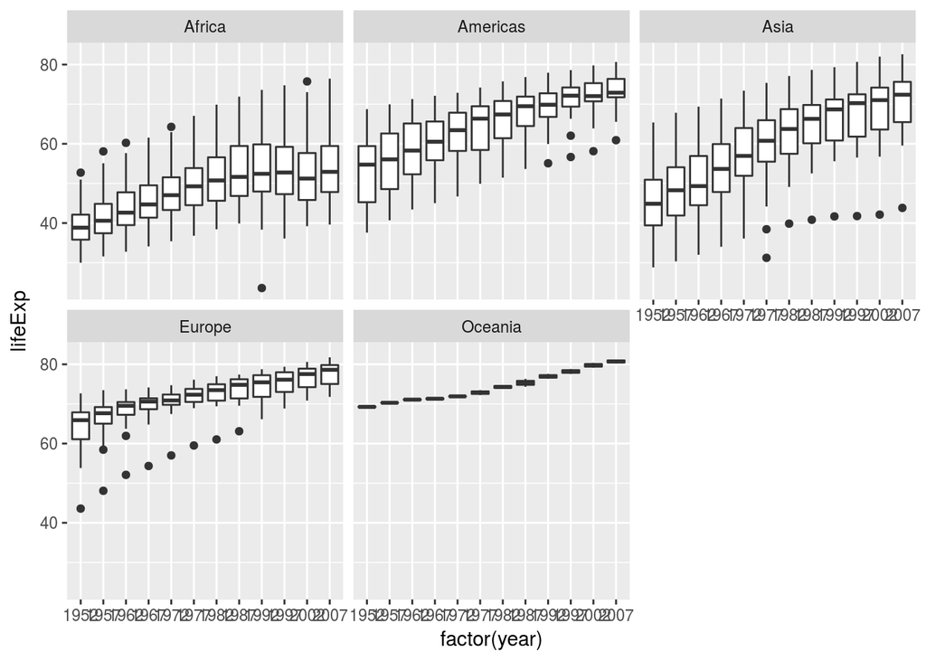

```r
library(ggplot2)
ggplot(data=gapminder,aes(x=factor(year),y=lifeExp))+geom_boxplot()+facet_wrap(~continent)
```

Al graficar la distribución anual de la expectativa de vida separada por continentes a lo largo de los años esperaríamos que este dato fuera creciente dado que es la tendencia general, lo interesante es ver por ejmplo el caso de Africa donde pareciera que la expectativa de vida esta estancada desde hace 25 años lo cual suena lógico dado que Africa es el continente más subdesarrollado y habría que preguntarse que paises contribuyen mayormente a este efecto. A pesar de la tendencia ha sido creciente en el resto de los continentes podemos ver que en Europa desde hace 20 años prácticamente han dejado de haber casos aislados de paises con menor expectativa de vida caso contrario a América y Asia donde en los más recienes años han habido paises con expectativas menores al resto.

```r
library(Hmisc)
```

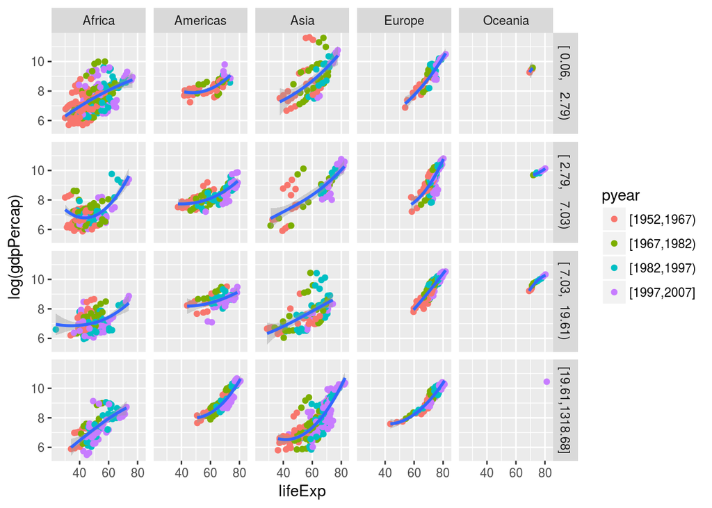

```r
gapminder$popx<-gapminder$pop/1000000
gapminder$pcap <- cut2(gapminder$popx, g = 4)
gapminder$pyear <- cut2(gapminder$year, g = 4)
ggplot(data=gapminder,aes(x=lifeExp,y=log(gdpPercap)))+geom_point(aes(color=pyear))+geom_smooth(span=3)+
  facet_grid(pcap~continent)
```

Relación expectativa de vida vs. pib per cápita.-en este sentido se hizo una partición en cuártiles del tamaño de la población y se colorea por bloques de años, es interesante observar que la relación entre estas variables es ineal y creciente es decir a mayor esperanza de vida mayor pib per cápita, podemos ver que esto es distinto si lo observamos por continente y tamaño de población delos países en distintos años, por ejemplo dentro de grupo de paises más poblados la relación de pib y esperanza de vida es exponencial, excepto en los paises africanos que es lineal y ligeramente a la baja en los últimos 10 años, por otro lado el cuártil de más población en Asia muestra la relación de crecimiento exponencial más marcado que cualquier otro rubro y sobretodo en los ultimos años, china está en este grupo se intuye su influencia. Loa paises menos poblados en Africa no mejoran la relaión entre variables con respecto a los mas poblados por tanto el tamaño de población pareciera no influir. También podemos observar que las relaciones en los paises Europeos son muy parecidas(lineales) independientemente del tamaño de poblaciones, incluso los paises con más población tienen una relación más exponencial entre variables que el resto además con décadas distintas. El caso de América es muy parecido al Europeo los paises más poblados cumplen más claro ue a mayor esperanza de vidamayor pib pc y pareciera que esto ha sido así independientemente de los años, para el caso de paises de entre 7 y 20 millones de habitantes en América pareciera que no hay una relación o es de muy poco crecimiento entre las variables excepto por las útimas 2 décadas, como en Africa en el mismo cuártil de población.

```r
Mex<-subset(gapminder,gapminder$country=="Mexico")
Mex$exp<-cut2(Mex$lifeExp,g=4)
Mex
```

```
## # A tibble: 12 × 10
##    country continent  year lifeExp       pop gdpPercap      popx
##     <fctr>    <fctr> <int>   <dbl>     <int>     <dbl>     <dbl>
## 1   Mexico  Americas  1952  50.789  30144317  3478.126  30.14432
## 2   Mexico  Americas  1957  55.190  35015548  4131.547  35.01555
## 3   Mexico  Americas  1962  58.299  41121485  4581.609  41.12148
## 4   Mexico  Americas  1967  60.110  47995559  5754.734  47.99556
## 5   Mexico  Americas  1972  62.361  55984294  6809.407  55.98429
## 6   Mexico  Americas  1977  65.032  63759976  7674.929  63.75998
## 7   Mexico  Americas  1982  67.405  71640904  9611.148  71.64090
## 8   Mexico  Americas  1987  69.498  80122492  8688.156  80.12249
## 9   Mexico  Americas  1992  71.455  88111030  9472.384  88.11103
## 10  Mexico  Americas  1997  73.670  95895146  9767.298  95.89515
## 11  Mexico  Americas  2002  74.902 102479927 10742.441 102.47993
## 12  Mexico  Americas  2007  76.195 108700891 11977.575 108.70089
## # ... with 3 more variables: pcap <fctr>, pyear <fctr>, exp <fctr>
```

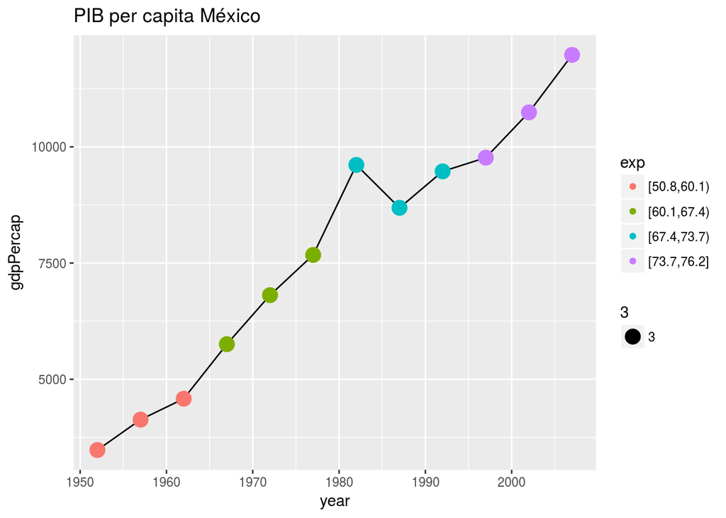

```r
ggplot(data=Mex)+geom_line(aes(x=year,y=gdpPercap))+
  geom_point(aes(x=year,y=gdpPercap,color=exp,size=3))+ggtitle('PIB per capita México')
```

Para el caso de México podemos observar que el pib per cápita entre los años 1987-1992 tuvo una importante baja con respecto a los 5 años anteriores y hasta el año 92 e recupero casi el nivel de 1982 es decir hubo un estancamieto en 10 años en estos ños la esperanza de vida estaba entre los 67 a 74 años, factor que cambió hasta 1997.